# RNAseq using Deseq2 and Functional enrichment Analysis

2022-04-16

##RNAseq using Deseq2 and Functional enrichment Analysis  
Dr. Amarinder Singh Thind and Simarpreet Kaur  
Date : 18-19 April, 2022

```r
##### Install packages, if not done before

# if (!requireNamespace("BiocManager", quietly = TRUE)) install.packages("BiocManager")
# BiocManager::install("DESeq2")
# BiocManager::install("biomaRt")
# BiocManager::install('PCAtools')
# BiocManager::install('EnhancedVolcano')
```

```r
###################### load the raw count matrix #######################

#setwd("/Users/athind/Dropbox/RNAseq_using_DEseq2-april16/") #Path_to_working_directory

setwd("./")
rawcount<-read.table ("RawCount_input.csv",header=TRUE,  sep=",",  row.names=1)

## Replace NAs by zero and
rawcount <- round(rawcount)
rawcount[is.na(rawcount)] <- 0
```

```r
###################### Data annotation  #################################

anno <-read.table ("Annotation_of_samples_12_Samples_ALL.csv",header=TRUE,  sep=",", row.names = 1) ##In this case we have 3 coulmns (a) sample (b) Condition (c) batch
#rownames(anno) <- anno$sample  ##add rownames as sample name (if not already), because pca function check rownames of anno == col of data matrix

##############################################################
```

### PCA plot for pre DE investigation

```r
############ PCA plot for pre DE investigation ##############


library(PCAtools)
anno <- anno[match(colnames(rawcount), anno$Sample),] ## reordering anno row with colnmaes of rawcount
lograwcount <- as.matrix(log2(rawcount +1))  ## log transformation of rawcount for PCA plot

top1000.order <- head(order(matrixStats::rowVars(lograwcount), decreasing = TRUE), 1000)
p <- PCAtools::pca(mat = lograwcount[top1000.order,], metadata = anno, removeVar = 0.01)
```

```
## -- removing the lower 1% of variables based on variance
```

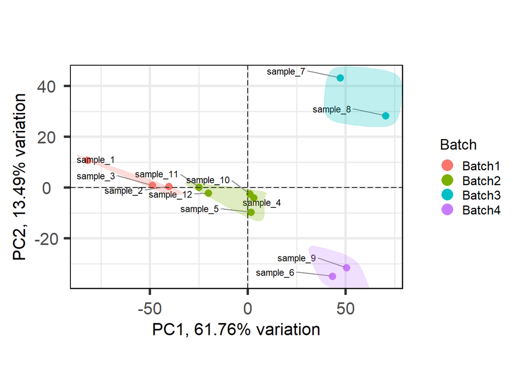

```r
biplot(p,lab = paste0(p$metadata$Sample),
        colby = 'Batch',  #Sample #Batch #Condition #sex
        hline = 0, vline = 0,
        legendPosition = 'right',
        encircle = T )
```

### Lets check combat normalization

```r
##############################################################
################# Lets check combat normalization ############
############## SVA #####################

  #BiocManager::install("sva")

library('sva')
rawcount <- as.matrix(rawcount)
adjusted_counts <- ComBat_seq(rawcount, batch=anno$Batch, group=anno$Condition) ##In ComBat-seq, user may specify biological covariates, whose signals will be preserved in the adjusted data. I
```

```
## Found 4 batches
## Using full model in ComBat-seq.
## Adjusting for 1 covariate(s) or covariate level(s)
## Estimating dispersions
## Fitting the GLM model
## Shrinkage off - using GLM estimates for parameters
## Adjusting the data
```

```r
nor_set <- as.matrix(log2(adjusted_counts+1)) ## log transformation of adjusted count
top1000.order <- head(order(matrixStats::rowVars(nor_set), decreasing = TRUE), 1000)
pp <- PCAtools::pca(mat =nor_set[top1000.order,] , metadata = anno, removeVar = 0.01)
```

```
## -- removing the lower 1% of variables based on variance
```

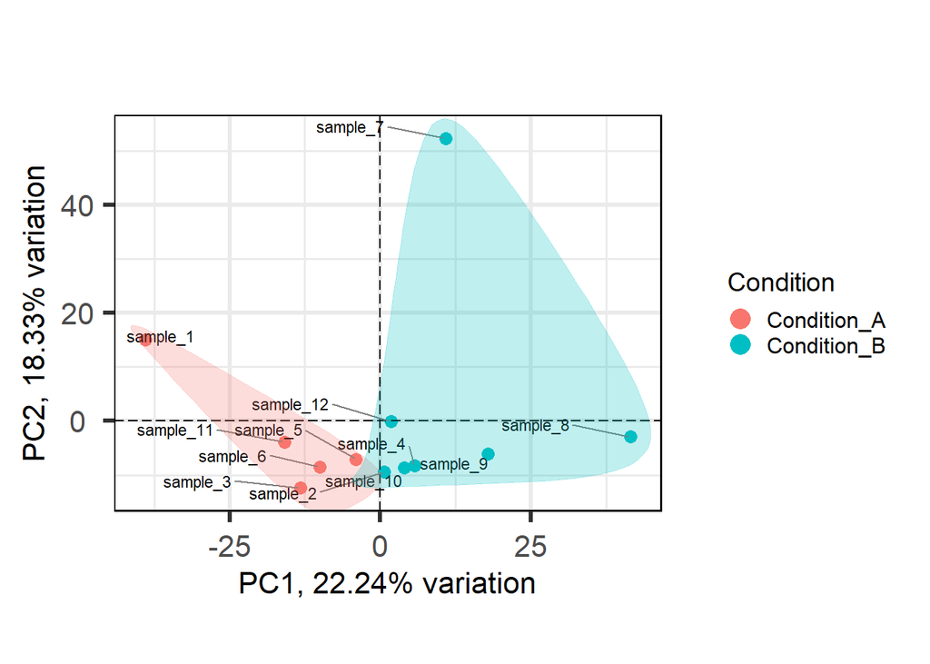

```r
biplot(pp,
      lab = paste0(p$metadata$Sample),
      #colby = 'Batch',   #Batch_log', #Condition
      colby = 'Condition',
      hline = 0, vline = 0,
      legendPosition = 'right',encircle = T)
```

```r
  ##### Do we suppose to remove any defaulty sample  #########

   ### subset raw and conditional data for defined pairs
   ##### Removing sample number 7 ##########

anno <- anno[!(anno$Sample == 'sample_7' | anno$Sample == 'sample_8'),]
rawcount <- as.data.frame(rawcount)
rawcount <- rawcount[,names(rawcount) %in% anno$Sample]

### Go back to PCA plot and check what happned
### perform combat normalization again after removal of sample

# Define conditions (for contrast) that you want to compare if you have more than one #control #case
# This is pair-wise comparison, so only consider one pair at one time

firstC<-"Condition_A"       #case1 #case2 #case3 etc
SecondC <-"Condition_B"
p.threshold <- 0.05   ##define threshold for filtering
```

### DESeq2 Analysis

```r
############################### Create DESeq2 datasets #############################
library(DESeq2)
##dds <- DESeqDataSetFromMatrix(countData = rawcount, colData = anno, design = ~Condition )   ##rawcount
dds <- DESeqDataSetFromMatrix(countData = rawcount, colData = anno, design =  ~Batch+Condition )  ###USE this one if you have extra col in anno data with Batch info
#dds = DESeq2::DESeqDataSetFromMatrix(countData = adjusted_counts, colData = anno, design = ~ Condition)  ##https://github.com/zhangyuqing/ComBat-seq/issues/7

##When considering batch effects in group design, it takes into account the mean differences across batch,
##not necessarily the variance differences. ComBat-Seq is designed to address both mean and variance batch effects.
###In theory, no, you do not need to include batch as a covariate any more. However, you can always try both and evaluate the results.
```

When considering batch effects in group design, it takes into account the mean differences across batch, not necessarily the variance differences. ComBat-Seq is designed to address both mean and variance batch effects. In theory, no, you do not need to include batch as a covariate any more. However, you can always try both and evaluate the results.

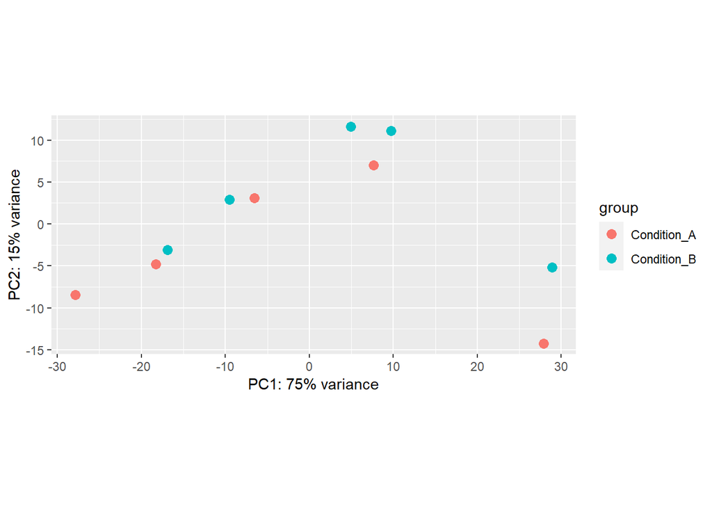

```r
#View(counts(dds))

dds <- estimateSizeFactors(dds)
normalized_counts <- counts(dds, normalized=TRUE)  ## extract normalization count after executing Deseq2 for visualization purpose
vst <- vst(dds, blind=TRUE)  ### Transform counts for data visualization #options (1) vst (2) rld
plotPCA(vst, intgroup="Condition")  ### Plot PCA
```

```r
## Run DESEQ2
dds <- DESeq(dds)
```

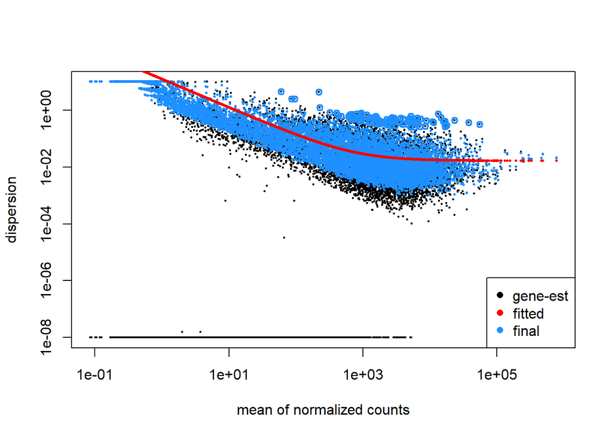

```r
##ensure your data is a good fit for the DESeq2 model
plotDispEsts(dds)
```